# Mutants 2022 PI data processing

R Guerillot, S Giulieri

29/03/2022

```r
library(tidyverse)
library(here)
library(patchwork)
knitr::opts_chunk$set(echo = TRUE)
knitr::opts_knit$set(root.dir = here())
print(paste("My working directory is:" ,here()))
```

```
## [1] "My working directory is: /Users/giulieris/OneDrive - The University of Melbourne/R/VANANZ_phenotypes_github"
```

# Source all function

```r
rm(list = ls())
source("Functions/all_functions.R")
```

# Import all NEB PI data (plate GP-C1 only)

```r
df_PI_raw <- list.files(path="Data_parsing/parsed_experiments/", pattern="PI_data_plateGP-C1", full.names=TRUE, recursive=T) %>%
  map_df(~read_csv(., col_types = cols(well_row = col_factor(),
                                      well_col = col_factor(),
                                      f_signal = col_integer(),
                                      well = col_factor(),
                                      experiment = col_factor(),
                                      cell_type = col_factor(),
                                      cell_number = col_factor(),
                                      plate = col_factor(),
                                      well_id = col_factor(),
                                      timepoint = col_integer(),
                                      sample_id = col_factor(),
                                      strain_group = col_factor()))) %>%
  mutate(experiment_id = str_c(experiment, "_", plate))   # Create a experiment variable that is unique
```

# Count plates

```r
n_plates <- df_PI_raw %>% select(experiment_id) %>% distinct() %>% nrow()
print(glue::glue("Total number of GP-C1 experiments included: {n_plates}"))
```

```
## Total number of GP-C1 experiments included: 5
```

```r
nb_replicate_plate.df <- df_PI_raw %>% select(experiment, plate) %>% distinct() %>% count(plate,name = "number of plate replicate") %>% print()
```

```
## # A tibble: 1 × 2
##   plate `number of plate replicate`
##   <fct>                       <int>
## 1 GP-C1                           5
```

```r
rm(n_plates, nb_replicate_plate.df)
```

# Check timepoints interval

```r
for (exp in df_PI_raw$experiment_id %>% unique()) {
  print(paste(exp,
               df_PI_raw %>%
                 filter(experiment_id == exp) %>%
                 .$timepoint %>%
                 unique() %>%
                 sort() %>%
                 .[[2]],
              "min"
  )
  )

}
```

```
## [1] "exp220303_GP-C1 5 min"
## [1] "exp220308_GP-C1 5 min"
## [1] "exp220309_GP-C1 5 min"
## [1] "exp220316_GP-C1 5 min"
## [1] "exp220328_GP-C1 5 min"
```

```r
rm(exp)
```

# Process PI kinetics data

## Check JE2 reference outlier in each plate

Use stringent criteria to detect JE2 outlier curves

Timepoint is outlier if: 1. |x| > 1.5 x IQR (Tukey’s fences method = box plot outlier detection method) 2. sd > 0.2 (Only timepoints with important variation are considered; sd > 20% of JE2 max) Curve is outlier if: 1. > 5% of timepoints are outliers (outlier_tukey_proportion = 0.05)

Notes: - 3 x sd and 3 x mad methods don’t identify more oulier curves as 0.05 proportion threshold; tukey is the most stringent method and therefore the only method used here - sd > 0.2 has been empirically set to avoid flagging outliers with very little variations. Could be improved by defining the sample_id~timepoints wise sd across all dataset

```
## Identifying JE2 outliers:
```

```
## Cutting to shortest experiment:  1360  min /  22.6666666666667  hours
```

```
## [1] "Please check the number of JE2 replicate(s) per experiment that will be used for standardisation:"
##     experiment_id plate sample_id n
## 1 exp220303_GP-C1 GP-C1       JE2 5
## 2 exp220308_GP-C1 GP-C1       JE2 5
## 3 exp220309_GP-C1 GP-C1       JE2 5
## 4 exp220316_GP-C1 GP-C1       JE2 5
## 5 exp220328_GP-C1 GP-C1       JE2 5
```

```
##
## Fitting PI signal for cell death using standardised data
```

```
## [1] "Total number of curves: 25"
## [1] "Total number of outliers detected: 4"
## [1] "Percentage of outliers detected: 16 %"
## [1] "Outliers curves:"
##               well_id sample_id   experiment_id plate
## 1 exp220308_GP-C1_B08       JE2 exp220308_GP-C1 GP-C1
## 2 exp220309_GP-C1_C04       JE2 exp220309_GP-C1 GP-C1
## 3 exp220309_GP-C1_D05       JE2 exp220309_GP-C1 GP-C1
## 4 exp220309_GP-C1_F04       JE2 exp220309_GP-C1 GP-C1
```

```
## Basic plot for all Plate GP-C1 - fitted smooth spline created
```

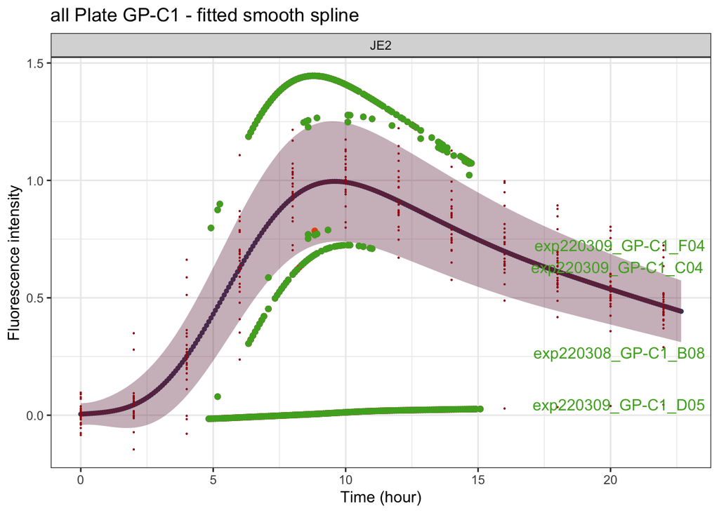

```r
df_PI_raw_check <- df_PI_raw %>%
  check_reference(reference = "JE2",
                  outlier_tukey_proportion = 0.05, # 1.5 x IQR used
                  outlier_sd_proportion = 1,       # 3 x sd not used
                  outlier_mad_proportion = 1,      # no 3 x mad not used
                  k_tukey = 1.5,
                  min_sd = 0.2,
                  filter = F,
                  plot = T)
```

### Plot JE2 non outliers and oultiers only

```r
p1 <- df_PI_raw_check %>%
  filter(!outlier_curve) %>%
  plot_cell_death(fitted = T, all_replicates = T, return_plots = T, print_plot = F,
                  subtitle = "Non-outlier curves")
```

```
## Basic plot for all Plate GP-C1 - fitted smooth spline created
```

```r
p2 <- df_PI_raw_check %>%
  filter(outlier_curve) %>%
  plot_cell_death(fitted = T, all_replicates = T, return_plots = T, print_plot = F,
                  annotate = T,
                  subtitle = "Outlier curves")
```

```
## Basic plot for all Plate GP-C1 - fitted smooth spline created
```

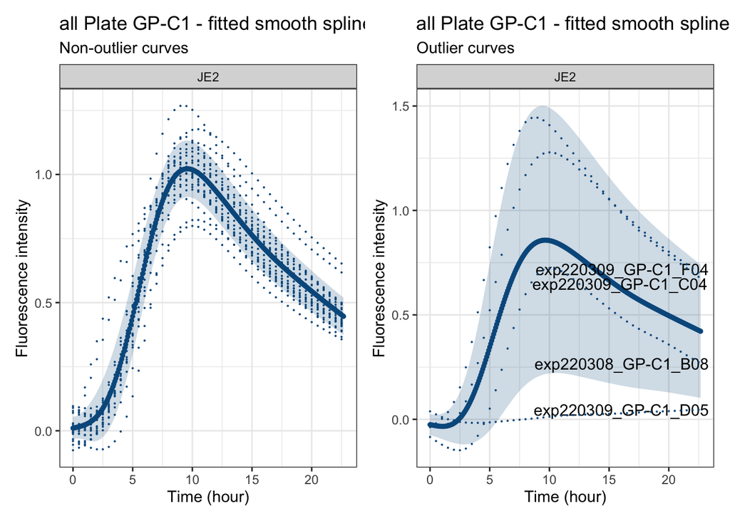

```r
p1 + p2
```

```r
rm(p1,p2)
```

### Count number of JE2 outliers per experiment

```r
JE2_outliers_exp_count <- df_PI_raw_check %>%
  filter(sample_id == "JE2") %>%
  select(experiment_id, well_id, outlier_curve) %>%
  distinct(.) %>%
  group_by(experiment_id) %>%
  mutate(total_JE2 = n()) %>%
  ungroup() %>%
  group_by(experiment_id, outlier_curve) %>%
  mutate(number_curve = n()) %>%
  ungroup() %>%
  select(-well_id) %>%
  distinct() %>%
  filter(outlier_curve == T) %>%
  mutate(remaining_non_JE2_outliers = total_JE2 - number_curve) %>%
  select(experiment_id, outlier_curve, number_curve, total_JE2, remaining_non_JE2_outliers) %>%
  print()
```

```
## # A tibble: 2 × 5
##   experiment_id   outlier_curve number_curve total_JE2 remaining_non_JE2_outlie…
##   <chr>           <lgl>                <int>     <int>                     <int>
## 1 exp220308_GP-C1 TRUE                     1         5                         4
## 2 exp220309_GP-C1 TRUE                     3         5                         2
```

### Identifiy all well_id corresponding to JE2 ouliers from dataset

```r
JE2_outliers_well <- df_PI_raw_check %>%
  filter(outlier_curve == T) %>%
  .$well_id %>%
  unique() %>%
  print()
```

```
## [1] exp220308_GP-C1_B08 exp220309_GP-C1_C04 exp220309_GP-C1_D05
## [4] exp220309_GP-C1_F04
## 25 Levels: exp220303_GP-C1_B08 exp220303_GP-C1_C04 ... exp220328_GP-C1_F04
```

### Identify all experiment_id with < 2 JE2 non outlier

```r
JE2_outliers_exp <- JE2_outliers_exp_count %>%
  filter(remaining_non_JE2_outliers < 2) %>%
  print() %>%
  .$experiment_id
```

```
## # A tibble: 0 × 5
## # … with 5 variables: experiment_id <chr>, outlier_curve <lgl>,
## #   number_curve <int>, total_JE2 <int>, remaining_non_JE2_outliers <int>
```

Based on JE2 outlier detection: no experiment will be excluded (all with >= 2 valid [non-outlier] curves)

### Check how many plates with < 3 JE3 non-oulier

```r
JE2_outliers_exp_count %>%
  filter(remaining_non_JE2_outliers < 3)
```

```
## # A tibble: 1 × 5
##   experiment_id   outlier_curve number_curve total_JE2 remaining_non_JE2_outlie…
##   <chr>           <lgl>                <int>     <int>                     <int>
## 1 exp220309_GP-C1 TRUE                     3         5                         2
```

```r
rm(JE2_outliers_exp_count)
```

## Clean raw PI data:

1. remove JE2 well outliers
2. remove experiments with < 2 JE2
3. standardise (with max time cutting)
4. fit curves
5. indentify and remove outliers (default parameter with tukey + mad + sd proportion > 0.1 (>10% outlier timepoints))
6. calculate derivatives

```r
df_PI_clean_with_outliers <- df_PI_raw %>%
  filter(!well_id %in% JE2_outliers_well) %>%
  filter(!experiment_id %in% JE2_outliers_exp) %>%
  standardise_curves(cut = T) %>%
  fit_curves(use_standardised = T) %>%
  flag_outlier_curves(use_standardised = T,
                      min_sd = 0.2,
                      k_sd = 3,
                      k_mad = 3,
                      k_tukey = 1.5,
                      outlier_tukey_proportion = 0.1,
                      outlier_sd_proportion = 0.1,
                      outlier_mad_proportion = 0.1,
                      filter = F) %>%
  get_derivatives(use_fitted = T)
```

```
## Cutting to shortest experiment:  1360  min /  22.6666666666667  hours
```

```
## [1] "Please check the number of JE2 replicate(s) per experiment that will be used for standardisation:"
##     experiment_id plate sample_id n
## 1 exp220303_GP-C1 GP-C1       JE2 5
## 2 exp220308_GP-C1 GP-C1       JE2 4
## 3 exp220309_GP-C1 GP-C1       JE2 2
## 4 exp220316_GP-C1 GP-C1       JE2 5
## 5 exp220328_GP-C1 GP-C1       JE2 5
```

```
##
## Fitting PI signal for cell death using standardised data
```

```
## [1] "Total number of curves: 284"
## [1] "Total number of outliers detected: 4"
## [1] "Percentage of outliers detected: 1.40845070422535 %"
## [1] "Outliers curves:"
##               well_id      sample_id   experiment_id plate
## 1 exp220308_GP-C1_E10         NE1140 exp220308_GP-C1 GP-C1
## 2 exp220309_GP-C1_E11        BPH3370 exp220309_GP-C1 GP-C1
## 3 exp220309_GP-C1_F05        BPH3370 exp220309_GP-C1 GP-C1
## 4 exp220309_GP-C1_G11 Complete lysis exp220309_GP-C1 GP-C1
```

```
## Calculating 1st and 2nd derivatives from fitted data
```

```r
df_PI_clean <- df_PI_clean_with_outliers %>%
  filter(!outlier_curve) %>%
  as_tibble()

# check that sample_id is not NA
df_PI_clean %>% filter(is.na(sample_id))
```

```
## # A tibble: 0 × 38
## # … with 38 variables: well_id <fct>, timepoint <dbl>, f_signal.fitted <dbl>,
## #   f_signal.residual <dbl>, experiment_id <chr>, well <fct>, f_signal <int>,
## #   well_row <fct>, well_col <fct>, experiment <fct>, cell_type <fct>,
## #   cell_number <fct>, plate <fct>, sample_id <fct>, strain_group <fct>,
## #   strain_description <chr>, n replicate/plate <dbl>, background <chr>,
## #   mutation to introduce <chr>, nucleotide_change <chr>,
## #   nucleotide_position <chr>, pam_gene <chr>, comment <chr>, …
```

### Count clean plates remaining

```r
n_plates <- df_PI_clean %>% select(experiment_id) %>% distinct() %>% nrow()
print(glue::glue("Total number of validate GPV1 experiments: {n_plates}"))
```

```
## Total number of validate GPV1 experiments: 5
```

```r
clean_PI_plate_count.df <- df_PI_raw %>% select(experiment, plate) %>% distinct() %>% count(plate,name = "number of plate replicate") %>% print()
```

```
## # A tibble: 1 × 2
##   plate `number of plate replicate`
##   <fct>                       <int>
## 1 GP-C1                           5
```

```r
rm(n_plates, clean_PI_plate_count.df)
```

### Count proportion of outlier wells per plate

```r
ratio_outlier.df <- df_PI_clean_with_outliers %>%
  select(well_id, experiment_id, outlier_curve) %>%
  distinct() %>%
  mutate(outlier_curve = factor(outlier_curve, levels = c(T,F))) %>%
  complete(outlier_curve) %>%
  count(experiment_id, outlier_curve, .drop = F) %>%
  group_by(experiment_id) %>%
  summarise(outlier = paste(outlier_curve, collapse = "/"), ratio_outlier = paste(n, collapse = "/")) %>%
  ungroup() %>%
  separate(col = ratio_outlier, sep = "/", into = c("outlier", "non_outlier")) %>%
  mutate(proportion_outlier = as.numeric(outlier)/as.numeric(non_outlier)) %>%
  arrange(-proportion_outlier) %>%
  print()
```

```
## # A tibble: 5 × 4
##   experiment_id   outlier non_outlier proportion_outlier
##   <chr>           <chr>   <chr>                    <dbl>
## 1 exp220309_GP-C1 3       54                      0.0556
## 2 exp220308_GP-C1 1       52                      0.0192
## 3 exp220303_GP-C1 0       54                      0
## 4 exp220316_GP-C1 0       60                      0
## 5 exp220328_GP-C1 0       60                      0
```

### Identify excluded isolate sample (outliers)

```r
excluded_sample <- setdiff(
df_PI_raw %>% .$sample_id%>% unique(),
df_PI_clean %>% .$sample_id%>% unique()
)

df_PI_raw %>% filter(sample_id %in% excluded_sample) %>%
  select(experiment_id, sample_id) %>%
  distinct()
```

```
## # A tibble: 0 × 2
## # … with 2 variables: experiment_id <chr>, sample_id <fct>
```

Overall, a very low proportion of outliers and no sample excluded! Good work Abdou!

### Asign plate replicate number

```r
df_PI_clean <- df_PI_clean %>%
  group_by(plate, experiment_id) %>%
  mutate(plate_replicate = cur_group_id())

df_PI_clean %>%
  distinct(plate, experiment_id, plate_replicate)
```

```
## # A tibble: 5 × 3
## # Groups:   plate, experiment_id [5]
##   experiment_id   plate plate_replicate
##   <chr>           <fct>           <int>
## 1 exp220303_GP-C1 GP-C1               1
## 2 exp220308_GP-C1 GP-C1               2
## 3 exp220309_GP-C1 GP-C1               3
## 4 exp220316_GP-C1 GP-C1               4
## 5 exp220328_GP-C1 GP-C1               5
```

```r
# check that sample_id is not NA
df_PI_clean %>% filter(is.na(sample_id))
```

```
## # A tibble: 0 × 39
## # Groups:   plate, experiment_id [0]
## # … with 39 variables: well_id <fct>, timepoint <dbl>, f_signal.fitted <dbl>,
## #   f_signal.residual <dbl>, experiment_id <chr>, well <fct>, f_signal <int>,
## #   well_row <fct>, well_col <fct>, experiment <fct>, cell_type <fct>,
## #   cell_number <fct>, plate <fct>, sample_id <fct>, strain_group <fct>,
## #   strain_description <chr>, n replicate/plate <dbl>, background <chr>,
## #   mutation to introduce <chr>, nucleotide_change <chr>,
## #   nucleotide_position <chr>, pam_gene <chr>, comment <chr>, …
```

### Set sample_id level to get controls first when plotting

Also fix order of NEB mutants to be consistent with the numerical order.

```r
df_PI_clean$sample_id %>%
  unique()
```

```
##  [1] Non infected   BPH3370-C4     NE873          BPH3370-A4     NE188
##  [6] NE1140         JE2            BPH3370-E2     BPH3370-F3     BPH3370-G3
## [11] TOX-4          BPH3370-D4     BPH3370-D3     BPH3370        NE119
## [16] NE1532         NE117          Complete lysis
## 18 Levels: Non infected BPH3370-C4 NE873 BPH3370-A4 NE188 NE1140 ... Complete lysis
```

```r
controls <- c("JE2", "BPH3370", "TOX-4", "Non infected", "Complete lysis")
neb_samples <- tibble(sample_id = str_subset(unique(df_PI_clean$sample_id), "NE")) %>%
  mutate(sample_id_numeric = as.integer(str_remove(sample_id, "NE"))) %>%
  arrange(sample_id_numeric) %>%
  .$sample_id
mutants <- str_subset(unique(df_PI_clean$sample_id), "BPH3370-")
blank <- "Blank"
levels <- c(controls, neb_samples, mutants, blank)


df_PI_clean <- df_PI_clean %>%
  mutate(sample_id = factor(sample_id, levels = levels)) %>%
  arrange(sample_id)

# check that sample_id is not NA
df_PI_clean %>% filter(is.na(sample_id))
```

```
## # A tibble: 0 × 39
## # Groups:   plate, experiment_id [0]
## # … with 39 variables: well_id <fct>, timepoint <dbl>, f_signal.fitted <dbl>,
## #   f_signal.residual <dbl>, experiment_id <chr>, well <fct>, f_signal <int>,
## #   well_row <fct>, well_col <fct>, experiment <fct>, cell_type <fct>,
## #   cell_number <fct>, plate <fct>, sample_id <fct>, strain_group <fct>,
## #   strain_description <chr>, n replicate/plate <dbl>, background <chr>,
## #   mutation to introduce <chr>, nucleotide_change <chr>,
## #   nucleotide_position <chr>, pam_gene <chr>, comment <chr>, …
```

## Extract PI curves parameters

```r
df_PI_clean_parameters <- df_PI_clean %>%
  get_parameters() %>%
  arrange(sample_id)
```

## Calculate sample parameters mean, median, sd, mad, IQR

```r
df_PI_clean_parameters_sample <- df_PI_clean_parameters %>%
  group_by(sample_id) %>%
  select(sample_id, ends_with("_death")) %>%
  summarise_if(is.numeric, funs(mean, sd, median, mad, IQR)) %>%
  merge(., df_PI_clean_parameters %>% select(sample_id, -ends_with("_death")) %>% distinct(), by = "sample_id") %>%
  arrange(sample_id)
```

# Plot fitted values

```
## Basic plot for all Plate GP-C1 - fitted smooth spline created
```

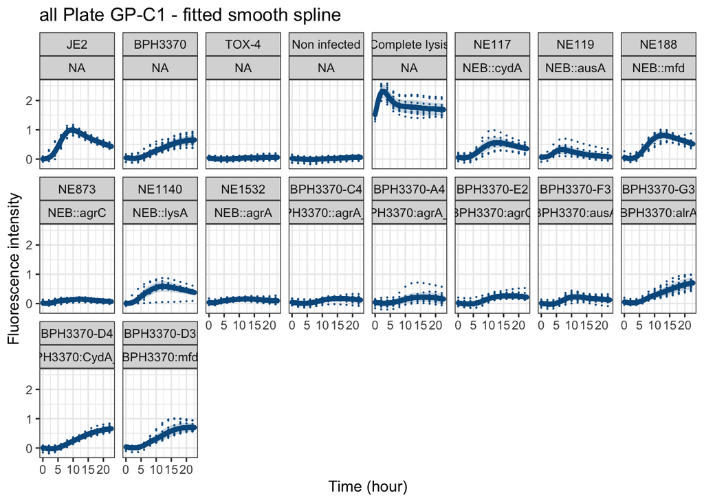

```r
# All samples (including "Complete lysis")
df_PI_clean %>%
  plot_cell_death(standardized = T, fitted = T, strain_description = T)
```

```
## Basic plot for all Plate GP-C1 - fitted smooth spline created
```

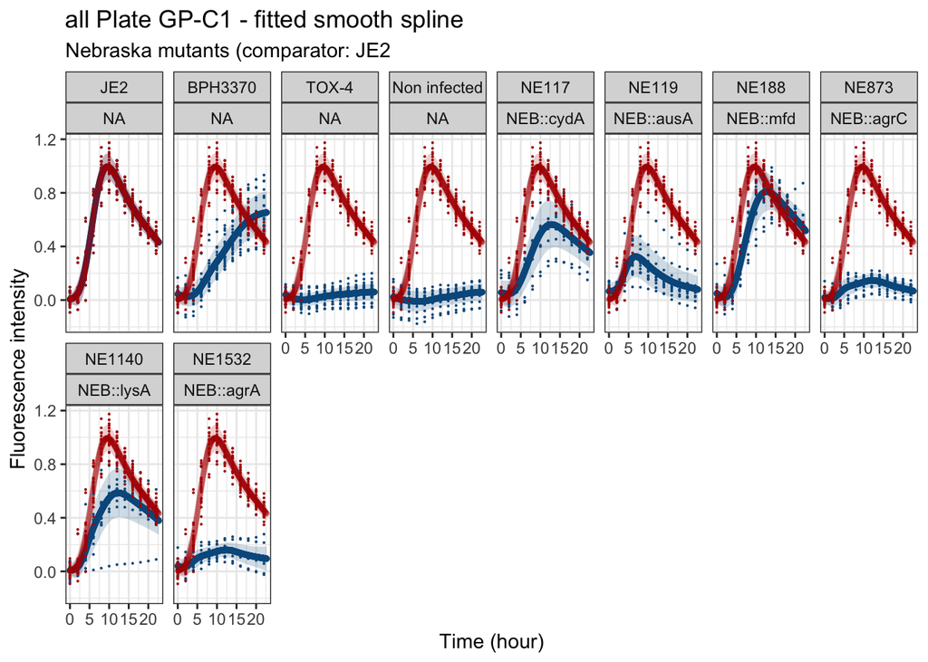

```r
# Nebraska mutants and controls
df_PI_clean %>%
  filter(sample_id %in% c(neb_samples, controls)) %>%
  filter(sample_id != "Complete lysis") %>%
  plot_cell_death(standardized = T, fitted = T, comparator = "JE2", strain_description = T,
                  subtitle = "Nebraska mutants (comparator: JE2")
```

```
## Basic plot for all Plate GP-C1 - fitted smooth spline created
```

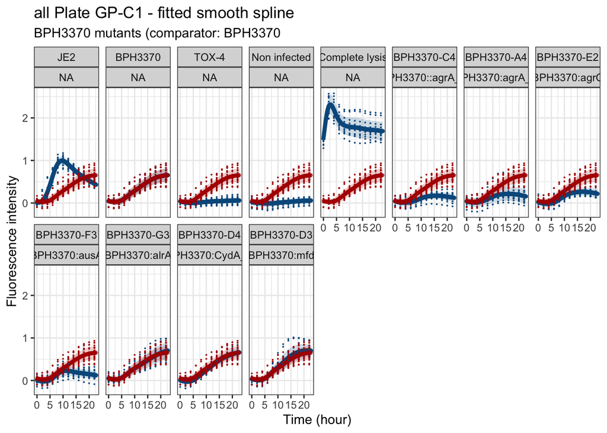

```r
# BPH3370 mutants and controls
df_PI_clean %>%
  filter(sample_id %in% c(mutants, controls)) %>%
  plot_cell_death(standardized = T, fitted = T, comparator = "BPH3370", strain_description = T,
                  subtitle = "BPH3370 mutants (comparator: BPH3370")
```

# Save data

## Save processed PI data

```r
# Save data as compressed R object (can be read with readRDS())
# advantage: all variable class are kept + factor order etc...
df_PI_clean %>%
  saveRDS("Mutants_2022/processed_data/PI_kinetics/PI_kinetics_plateGP-C1.Rda", compress = "gzip")
```

## Save PI curves parameters

```r
df_PI_clean_parameters %>%
  saveRDS("Mutants_2022/processed_data/PI_parameters/PI_parameters_plateGP-C1.Rda")

df_PI_clean_parameters_sample %>%
  saveRDS("Mutants_2022/processed_data/PI_parameters/PI_sample_parameters_plateGP-C1.Rda")
```